# Practica_5

#### Universidad Autónoma de Aguascalientes

#### Departamento: Ciencias de la Computación

#### Carrera: Ingenieria en Computación Inteligente

#### Curso: Machine Learning y Deep Learning

#### Maestro: Dr. Francisco Javier Luna Rosas

#### Alumno: Jorge Hernández

#### Semestre: Enero - Junio del 2025

PRACTICA No. 7. Descenso del Gradiente 2D

La idea principal es representar el error como una función continua de los pesos e intentar ilevar la red hacia una configuración de valores de activación que nos permita encontrar el mínimo de esta función.

Para determinar la magnitud y dirección del cambio que debemos introducir en el vector de pesos para reducir el error que está cometiendo, utilizaremos el concepto de «pendiente», que indica que la pendiente de un punto dado es el gradiente de la tangente a la curva de la función en el punto dado.

El gradiente es la derivada de una operación tensorial. Es la generalización del concepto de derivadas a funciones que toman fensores como entradas

Paso 1: Importar las librerías necesarias

```python
import numpy as np
import pandas as pd
import matplotlib.pyplot as plt
```

Paso 2: Definimos la funcion $$f(x) = 2x^2 * cos(x) -5x$$

```python
def funcion(x):
    return 2*(pow(x,2)) * np.cos(x) - 5 * x
```

Paso 3: Graficamos la funcion $$f(x) = 2x^2 * cos(x) -5x$$

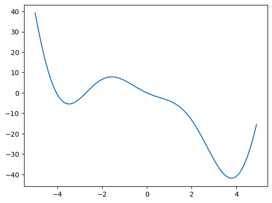

```python
t1 = np.arange(-5.0,5.0,0.1)

plt.plot(t1, funcion(t1))
plt.show()
```

PASO 4: IMPLEMENTAMOS EL ALGORITMO DEL DESCENSO DEL GRADIENTE

PASO 4_1: Tomar un punto al azar de X0

```
POS X: -1
POS Y: 6.0806046117362795
```

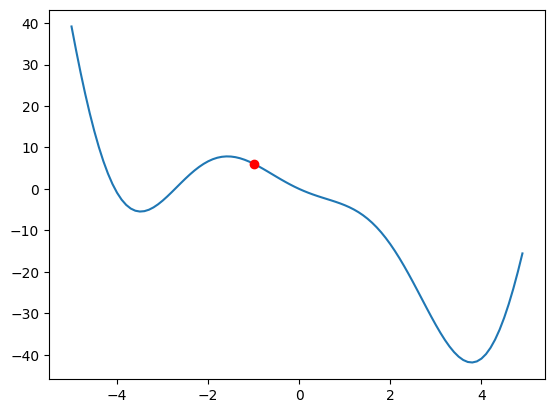

```python
t1 = np.arange(-5.0,5.0,0.1)
plt.plot(t1, funcion(t1))

point_x0 = [np.random.randint(-5,5)]
point_y0 = [funcion(point_x0[0])]

print(f"POS X: {point_x0[0]}")
print(f"POS Y: {point_y0[0]}")


plt.plot(point_x0,point_y0,'ro')

plt.show()
```

PASO 4_2: Calcular el valor de la pendiente (Primera Derivada) de f(x) $$-2x^2sin(x)+4xcos(x) -5 $$

```python
def funcion_primera_derivada(x):
    return (-2*pow(x,2)*np.sin(x) + 4*x*np.cos(x) - 5)
```

```python
pendiente = funcion_primera_derivada(point_x0[0])
print(f"Pendiente: {pendiente}")
```

```
Pendiente: -5.478267253856766
```

PASO 4_3: Camine en direccion opuesta a la pendiente $$x_1 = x_0 - eta * f'(x_0)$$

NOTA: ETA representa la Taza de Aprendizaje

```python
eta = 0.05

point_x0.append(point_x0[0] - eta * pendiente)
point_y0.append(funcion(point_x0[0] - eta * pendiente))

print(f"POS X: {point_x0}")
print(f"POS Y: {point_y0}")
```

```
POS X: [-1, -0.7260866373071617]
POS Y: [6.0806046117362795, 4.418893422871324]
```

PASO 4_4: Graficamos el punto 2

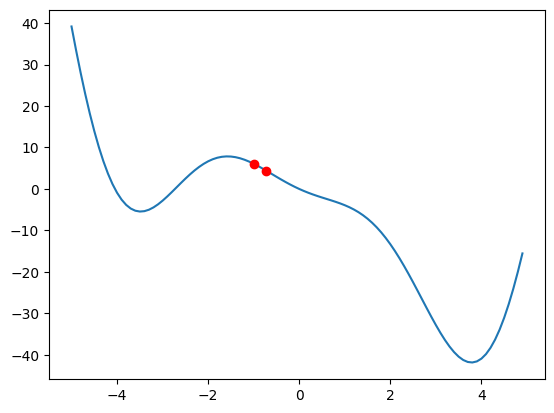

```python
t1 = np.arange(-5.0,5.0,0.1)
plt.plot(t1, funcion(t1))

plt.plot(point_x0,point_y0,'ro')

plt.show()
```

PASO 4_5: Graficamos el punto 3

```
POS X: [-1, -0.7260866373071617, -0.45217327461432344]
POS Y: [6.0806046117362795, 4.418893422871324, 2.6286909868495822]
Pendiente 0: -5.478267253856766
Pendiente 1: -6.471738005862216
Pendiente 2: -6.448252363504745
```

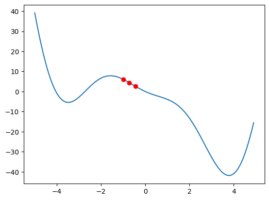

```python
point_x0.append(point_x0[1] - eta * pendiente)
point_y0.append(funcion(point_x0[1] - eta * pendiente))

print(f"POS X: {point_x0}")
print(f"POS Y: {point_y0}")

print(f"Pendiente 0: {funcion_primera_derivada(point_x0[0])}")
print(f"Pendiente 1: {funcion_primera_derivada(point_x0[1])}")
print(f"Pendiente 2: {funcion_primera_derivada(point_x0[2])}")

t1 = np.arange(-5.0,5.0,0.1)
plt.plot(t1, funcion(t1))

plt.plot(point_x0,point_y0,'ro')

plt.show()
```

#### PROCESO COMPLETO

```python
point_x0 = [np.random.randint(-5,5)]
point_y0 = [funcion(point_x0[0])]

print(f"POS X: {point_x0[0]}")
print(f"POS Y: {point_y0[0]}")
```

```
POS X: -1
POS Y: 6.0806046117362795
```

```python
epsilon = 1e-6
eta = 0.05
max_iter = 200

point_x0 = [0]
point_y0 = [funcion(point_x0[0])]

for i in range(max_iter):
    pendiente = funcion_primera_derivada(point_x0[i])  # Cálculo del gradiente
    nuevo_x = point_x0[i] - eta * pendiente
    nuevo_y = funcion(nuevo_x)

    if abs(nuevo_x - point_x0[i]) < epsilon:
        print(f"Se detiene en iteración {i}, cambio menor a {epsilon}")
        break

    point_x0.append(nuevo_x)
    point_y0.append(nuevo_y)

    print(f"Iteración {i}: x = {nuevo_x}, y = {nuevo_y}, pendiente = {pendiente}")
```

```
Iteración 0: x = 0.25, y = -1.1288859472861694, pendiente = -5.0
Iteración 1: x = 0.45310065365980856, y = -1.8963348675687965, pendiente = -4.06201307319617
Iteración 2: x = 0.6306117564011247, y = -2.510687036814903, pendiente = -3.550222054826322
Iteración 3: x = 0.802195145042049, y = -3.1163192838059937, pendiente = -3.431667772818487
Iteración 4: x = 0.9869305036525913, y = -3.8607757161407035, pendiente = -3.694707172210844
Iteración 5: x = 1.209387895084955, y = -5.0125985750517215, pendiente = -4.449147828647275
Iteración 6: x = 1.5106752618495998, y = -7.2791322462191985, pendiente = -6.025747335292896
Iteración 7: x = 1.970323175946548, y = -12.871810906651156, pendiente = -9.192958281938964
Iteración 8: x = 2.7312507632136818, y = -27.337168554895023, pendiente = -15.218551745342676
Iteración 9: x = 3.779739391468743, y = -41.84845045543498, pendiente = -20.969772565101216
Iteración 10: x = 3.7858636424266687, y = -41.848491637396975, pendiente = -0.12248501915851229
Iteración 11: x = 3.780403569543947, y = -41.8485234796453, pendiente = 0.10920145765443579
Iteración 12: x = 3.7852738944281867, y = -41.848549446721805, pendiente = -0.09740649768479948
Iteración 13: x = 3.7809315135579498, y = -41.848569640794835, pendiente = 0.08684761740473945
Iteración 14: x = 3.784804696146368, y = -41.8485860245503, pendiente = -0.07746365176836001
Iteración 15: x = 3.781351214010635, y = -41.84859882441711, pendiente = 0.06906964271466087
Iteración 16: x = 3.784431433262399, y = -41.8486091668202, pendiente = -0.061604385035280984
Iteración 17: x = 3.7816848925319544, y = -41.84861727636964, pendiente = 0.05493081460889471
Iteración 18: x = 3.7841345079385613, y = -41.84862380770737, pendiente = -0.048992308132135065
Iteración 19: x = 3.7819501978690044, y = -41.848628943842144, pendiente = 0.04368620139114121
Iteración 20: x = 3.783898319591013, y = -41.848633069753696, pendiente = -0.03896243444017067
Iteración 21: x = 3.782161151146129, y = -41.848636321789826, pendiente = 0.03474336889767926
Iteración 22: x = 3.7837104517332176, y = -41.848638928823036, pendiente = -0.03098601174177773
Iteración 23: x = 3.782328894075813, y = -41.84864098745247, pendiente = 0.02763115314809106
Iteración 24: x = 3.7835610235256323, y = -41.84864263508253, pendiente = -0.024642588996382386
Iteración 25: x = 3.7824622818533804, y = -41.848643938022676, pendiente = 0.021974833445034037
Iteración 26: x = 3.7834421728961156, y = -41.84864497948023, pendiente = -0.019597820854707848
Iteración 27: x = 3.782568353366535, y = -41.84864580401666, pendiente = 0.017476390591612656
Iteración 28: x = 3.7833476446965784, y = -41.84864646239885, pendiente = -0.015585826600863939
Iteración 29: x = 3.78265270434048, y = -41.84864698413, pendiente = 0.013898807121970336
Iteración 30: x = 3.7832724626624117, y = -41.84864740038357, pendiente = -0.012395166438636807
Iteración 31: x = 3.7827197835970683, y = -41.848647730483265, pendiente = 0.011053581306866178
Iteración 32: x = 3.7832126681972635, y = -41.84864799367509, pendiente = -0.009857692003903296
Iteración 33: x = 3.782773128356582, y = -41.84864820251465, pendiente = 0.008790796813627821
Iteración 34: x = 3.783165112419843, y = -41.848648368938, pendiente = -0.007839681265220833
Iteración 35: x = 3.782815551177546, y = -41.8486485010542, pendiente = 0.006991224845942057
Iteración 36: x = 3.7831272906451887, y = -41.848648606293494, pendiente = -0.006234789352852488
Iteración 37: x = 3.7828492885071983, y = -41.848648689869165, pendiente = 0.005560042759805484
Iteración 38: x = 3.7830972106625294, y = -41.84864875642084, pendiente = -0.004958443106621857
Iteración 39: x = 3.7828761187464006, y = -41.84864880928828, pendiente = 0.004421838322572924
```

[output cut: 33 more lines]

```
Iteración 73: x = 3.7829782235659635, y = -41.84864901470996, pendiente = 9.005672433026746e-05
Iteración 74: x = 3.78298223914638, y = -41.84864901472741, pendiente = -8.031160832899786e-05
Iteración 75: x = 3.782978658096684, y = -41.848649014741284, pendiente = 7.162099391599952e-05
Iteración 76: x = 3.7829818516377722, y = -41.84864901475232, pendiente = -6.387082175685066e-05
Iteración 77: x = 3.782979003673455, y = -41.848649014761094, pendiente = 5.6959286345303894e-05
Iteración 78: x = 3.7829815434569136, y = -41.84864901476808, pendiente = -5.0795669169545477e-05
Iteración 79: x = 3.7829792785062946, y = -41.84864901477363, pendiente = 4.529901238470302e-05
Iteración 80: x = 3.7829812983644575, y = -41.84864901477805, pendiente = -4.039716325543452e-05
Iteración 81: x = 3.78297949707739, y = -41.84864901478156, pendiente = 3.60257413465348e-05
Iteración 82: x = 3.782981103445443, y = -41.84864901478435, pendiente = -3.212736105950853e-05
Iteración 83: x = 3.7829796709042367, y = -41.84864901478657, pendiente = 2.865082412206732e-05
Iteración 84: x = 3.7829809484287544, y = -41.848649014788336, pendiente = -2.555049035635193e-05
Iteración 85: x = 3.782979809146548, y = -41.848649014789736, pendiente = 2.2785644123501925e-05
Iteración 86: x = 3.782980825145897, y = -41.84864901479085, pendiente = -2.031998698370785e-05
Se detiene en iteración 87, cambio menor a 1e-06
```

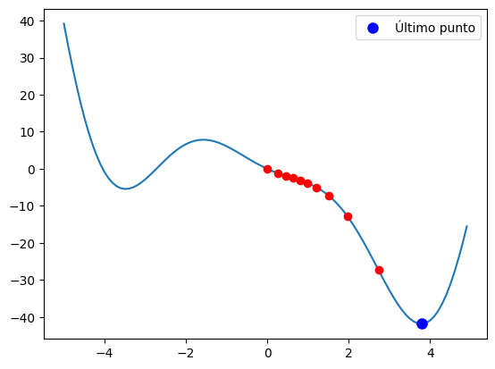

```python
t1 = np.arange(-5.0,5.0,0.1)

fig, ax = plt.subplots()
ax.plot(t1, funcion(t1))

plt.plot(point_x0,point_y0,'ro')
plt.plot(point_x0[-1], point_y0[-1], 'bo', markersize=8, label="Último punto")

plt.legend()
plt.show()
```

### CONCLUSION

El gradiente es la derivada de una operacion tensorial. Es la generalizacion del concepto de derivadas a funciones que toman tensores como entradas

#### BIBLIOGRAFIA

URL: KERAS (2025) https://keras.io/

Oldemar Rodriguez (2025). Reporte Técnico de PROMIDAT: http://promidat.com/ (Ultimo acceso febrero 2025).